# Phase 2 - Regression Analysis: Drivers of Data Center CO2 Emissions

Lakshay Mani

2026-03-30

## Overview

This analysis identifies which factors statistically drive CO2 emissions from U.S. data centers, using OLS regression with three predictors: energy consumption, grid carbon intensity, and renewable energy percentage.

**Data Sources:**

- LBNL 2024 US Data Center Energy Usage Report
- Ember (2026) via Our World in Data
- EIA Monthly Energy Review March 2026, Table 2.6

## Load Data

```r
library(ggplot2)
library(dplyr)

df <- read.csv("master_dataset.csv")
head(df)
```

```
##   Year DC_Energy_TWh Grid_CarbonIntensity_gCO2perKWh Renewable_Pct
## 1 2014          58.0                          529.41          5.99
## 2 2015          62.1                          504.90          6.15
## 3 2016          66.4                          483.35          6.84
## 4 2017          71.1                          469.02          7.82
## 5 2018          76.0                          462.61          7.79
## 6 2019          89.7                          439.45          8.69
##   Derived_CO2_MtCO2 LBNL_Predicted_CO2_MtCO2 Actual_CO2_MtCO2
## 1             30.71                    19.72               NA
## 2             31.35                    21.11               NA
## 3             32.09                    22.58               NA
## 4             33.35                    24.17               NA
## 5             35.16                    25.84             31.5
## 6             39.42                    30.50               NA
##   Data_Source_Energy
## 1          LBNL 2024
## 2          LBNL 2024
## 3          LBNL 2024
## 4          LBNL 2024
## 5          LBNL 2024
## 6          LBNL 2024
```

```r
str(df)
```

```
## 'data.frame':    11 obs. of  8 variables:
##  $ Year                           : int  2014 2015 2016 2017 2018 2019 2020 2021 2022 2023 ...
##  $ DC_Energy_TWh                  : num  58 62.1 66.4 71.1 76 ...
##  $ Grid_CarbonIntensity_gCO2perKWh: num  529 505 483 469 463 ...
##  $ Renewable_Pct                  : num  5.99 6.15 6.84 7.82 7.79 ...
##  $ Derived_CO2_MtCO2              : num  30.7 31.4 32.1 33.4 35.2 ...
##  $ LBNL_Predicted_CO2_MtCO2       : num  19.7 21.1 22.6 24.2 25.8 ...
##  $ Actual_CO2_MtCO2               : num  NA NA NA NA 31.5 NA NA NA NA NA ...
##  $ Data_Source_Energy             : chr  "LBNL 2024" "LBNL 2024" "LBNL 2024" "LBNL 2024" ...
```

## Correlation Analysis

Before regression, check how each variable relates to emissions.

```r
cor_matrix <- cor(df[, c("DC_Energy_TWh",
                          "Grid_CarbonIntensity_gCO2perKWh",
                          "Renewable_Pct",
                          "Derived_CO2_MtCO2")])
round(cor_matrix, 3)
```

```
##                                 DC_Energy_TWh Grid_CarbonIntensity_gCO2perKWh
## DC_Energy_TWh                           1.000                          -0.907
## Grid_CarbonIntensity_gCO2perKWh        -0.907                           1.000
## Renewable_Pct                           0.924                          -0.987
## Derived_CO2_MtCO2                       0.998                          -0.886
##                                 Renewable_Pct Derived_CO2_MtCO2
## DC_Energy_TWh                           0.924             0.998
## Grid_CarbonIntensity_gCO2perKWh        -0.987            -0.886
## Renewable_Pct                           1.000             0.909
## Derived_CO2_MtCO2                       0.909             1.000
```

## OLS Regression Model

```r
model <- lm(Derived_CO2_MtCO2 ~ DC_Energy_TWh +
                                  Grid_CarbonIntensity_gCO2perKWh +
                                  Renewable_Pct,
            data = df)
summary(model)
```

```
##
## Call:
## lm(formula = Derived_CO2_MtCO2 ~ DC_Energy_TWh + Grid_CarbonIntensity_gCO2perKWh +
##     Renewable_Pct, data = df)
##
## Residuals:
##      Min       1Q   Median       3Q      Max
## -1.25491 -0.39689  0.02248  0.22674  1.19403
##
## Coefficients:
##                                  Estimate Std. Error t value Pr(>|t|)
## (Intercept)                     -30.18611   23.29664  -1.296   0.2362
## DC_Energy_TWh                     0.35873    0.01438  24.943 4.25e-08 ***
## Grid_CarbonIntensity_gCO2perKWh   0.06434    0.03329   1.932   0.0946 .
## Renewable_Pct                     1.06495    1.09039   0.977   0.3613
## ---
## Signif. codes:  0 '***' 0.001 '**' 0.01 '*' 0.05 '.' 0.1 ' ' 1
##
## Residual standard error: 0.7962 on 7 degrees of freedom
## Multiple R-squared:  0.9981, Adjusted R-squared:  0.9973
## F-statistic:  1230 on 3 and 7 DF,  p-value: 6.874e-10
```

## Multicollinearity Check (VIF)

VIF values above 5 indicate high multicollinearity, above 10 are severe. Given the high correlations between predictors, this check confirms whether the full model coefficients should be interpreted with caution.

```r
if (!require(car)) install.packages("car", repos="http://cran.r-project.org")
library(car)
vif(model)
```

```
##                   DC_Energy_TWh Grid_CarbonIntensity_gCO2perKWh
##                        6.876093                       38.988860
##                   Renewable_Pct
##                       47.355268
```

## Visualize: Actual vs Fitted

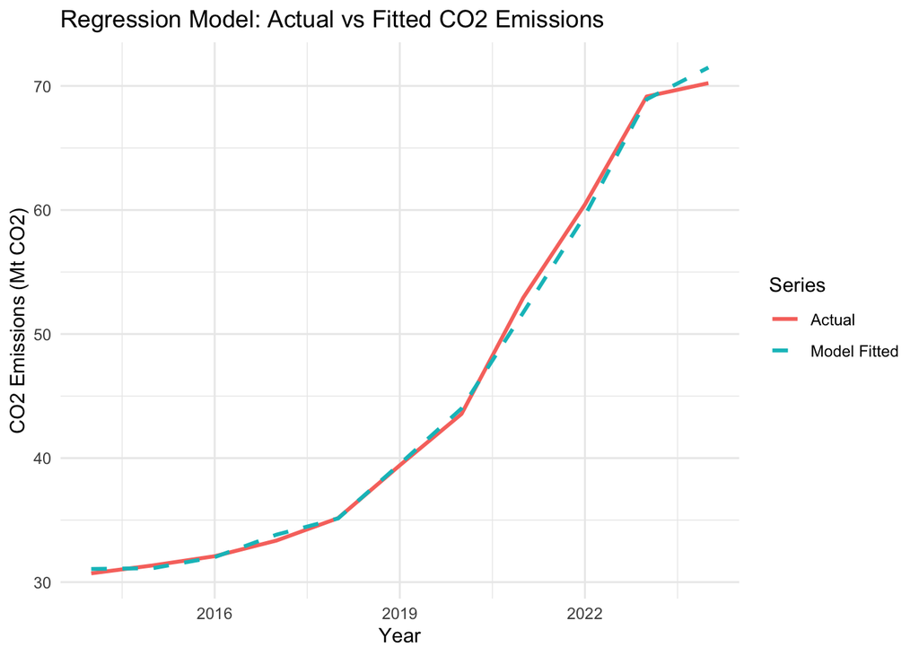

```r
df$Fitted <- fitted(model)

ggplot(df, aes(x = Year)) +
  geom_line(aes(y = Derived_CO2_MtCO2, color = "Actual"), linewidth = 1) +
  geom_line(aes(y = Fitted, color = "Model Fitted"),
            linetype = "dashed", linewidth = 1) +
  labs(title = "Regression Model: Actual vs Fitted CO2 Emissions",
       x = "Year", y = "CO2 Emissions (Mt CO2)",
       color = "Series") +
  theme_minimal()
```

## Individual Predictor Models

```r
# Model 1: Energy alone
model_simple <- lm(Derived_CO2_MtCO2 ~ DC_Energy_TWh, data = df)
summary(model_simple)
```

```
##
## Call:
## lm(formula = Derived_CO2_MtCO2 ~ DC_Energy_TWh, data = df)
##
## Residuals:
##     Min      1Q  Median      3Q     Max
## -1.8550 -0.5774 -0.2135  0.8182  1.2247
##
## Coefficients:
##               Estimate Std. Error t value Pr(>|t|)
## (Intercept)   10.20689    0.81660   12.50 5.44e-07 ***
## DC_Energy_TWh  0.33278    0.00715   46.54 4.89e-12 ***
## ---
## Signif. codes:  0 '***' 0.001 '**' 0.01 '*' 0.05 '.' 0.1 ' ' 1
##
## Residual standard error: 1.038 on 9 degrees of freedom
## Multiple R-squared:  0.9959, Adjusted R-squared:  0.9954
## F-statistic:  2166 on 1 and 9 DF,  p-value: 4.888e-12
```

```r
# Model 2: Carbon intensity alone
model_ci <- lm(Derived_CO2_MtCO2 ~ Grid_CarbonIntensity_gCO2perKWh, data = df)
summary(model_ci)
```

```
##
## Call:
## lm(formula = Derived_CO2_MtCO2 ~ Grid_CarbonIntensity_gCO2perKWh,
##     data = df)
##
## Residuals:
##     Min      1Q  Median      3Q     Max
## -11.732  -5.501   1.100   5.842   9.221
##
## Coefficients:
##                                 Estimate Std. Error t value Pr(>|t|)
## (Intercept)                     173.5570    22.4830   7.719 2.94e-05 ***
## Grid_CarbonIntensity_gCO2perKWh  -0.2872     0.0501  -5.733 0.000282 ***
## ---
## Signif. codes:  0 '***' 0.001 '**' 0.01 '*' 0.05 '.' 0.1 ' ' 1
##
## Residual standard error: 7.481 on 9 degrees of freedom
## Multiple R-squared:  0.785,  Adjusted R-squared:  0.7612
## F-statistic: 32.87 on 1 and 9 DF,  p-value: 0.0002822
```

```r
# Model 3: Renewables alone
model_ren <- lm(Derived_CO2_MtCO2 ~ Renewable_Pct, data = df)
summary(model_ren)
```

```
##
## Call:
## lm(formula = Derived_CO2_MtCO2 ~ Renewable_Pct, data = df)
##
## Residuals:
##     Min      1Q  Median      3Q     Max
## -8.5626 -5.9816  0.2996  5.3894  9.3515
##
## Coefficients:
##               Estimate Std. Error t value Pr(>|t|)
## (Intercept)    -28.077     11.433  -2.456 0.036411 *
## Renewable_Pct    8.753      1.342   6.523 0.000109 ***
## ---
## Signif. codes:  0 '***' 0.001 '**' 0.01 '*' 0.05 '.' 0.1 ' ' 1
##
## Residual standard error: 6.742 on 9 degrees of freedom
## Multiple R-squared:  0.8254, Adjusted R-squared:  0.806
## F-statistic: 42.55 on 1 and 9 DF,  p-value: 0.0001086
```

```r
# Compare R-squared across all three
cat("R-squared comparison:\n")
```

```
## R-squared comparison:
```

```r
cat("Energy alone:           ", round(summary(model_simple)$r.squared, 4), "\n")
```

```
## Energy alone:            0.9959
```

```r
cat("Carbon intensity alone: ", round(summary(model_ci)$r.squared, 4), "\n")
```

```
## Carbon intensity alone:  0.785
```

```r
cat("Renewables alone:       ", round(summary(model_ren)$r.squared, 4), "\n")
```

```
## Renewables alone:        0.8254
```

## Phase 2 Findings

OLS regression confirms **DC energy consumption** is the dominant driver of emissions (R² = 0.9959, p < 0.001). Every additional 1 TWh of data center energy adds **0.33 Mt CO2**.

Carbon intensity (R² = 0.785) and renewable percentage (R² = 0.825) are statistically significant when isolated but secondary to energy volume.

Note: High VIF values are expected given the strong correlation between energy growth and renewable adoption over time. Individual predictor models are therefore the cleaner analytical lens.

**Implication:** LBNL’s emissions underestimate is not from mispredicting energy growth — it’s from underestimating the carbon intensity of the specific grids powering data centers.